# umap

## 対象遺伝子の個別関連検定と相関係数

全対象遺伝子のMantel相関係数とMantel_p_1の分布を確認する。

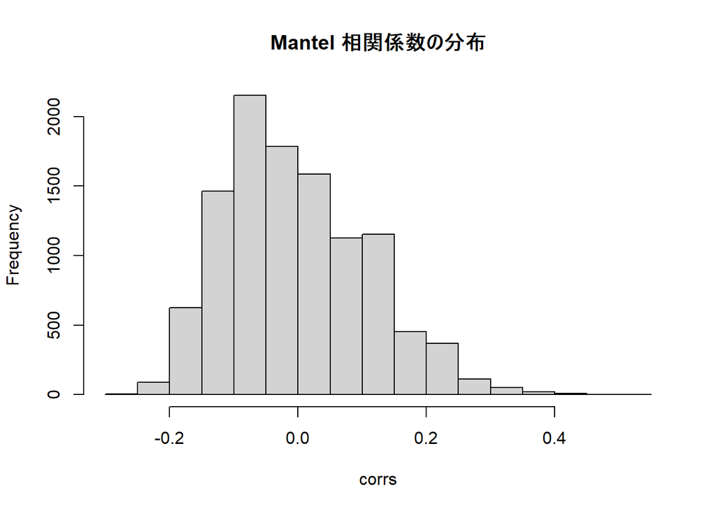

```r
hist(corrs,main="Mantel 相関係数の分布")
```

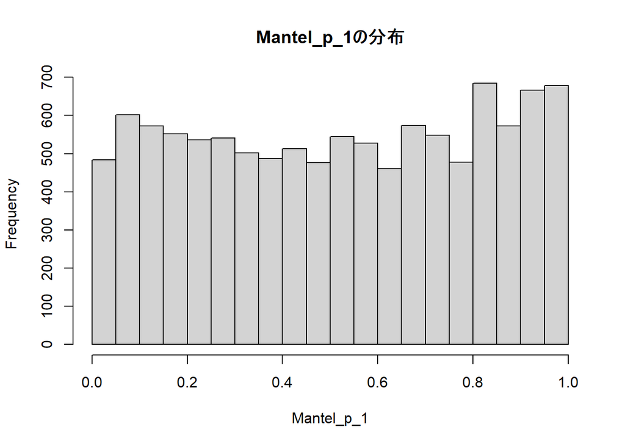

```r
hist(Mantel_p_1,main="Mantel_p_1の分布")
```

### Mantel_p_1 < 0.002 の遺伝子につき、Mantel_p_2を計算する

```r
selected_genes <- which(Mantel_p_1 < 0.002)
length(selected_genes)
```

```
## [1] 17
```

```r
Mantel_p_2 <- rep(0,length(selected_genes))
dist_mat_x <- GraphDistMatX[[k.sm-1]]
for(i in 1:length(selected_genes)){
  this.gene <- data_y[,selected_genes[i]]
  if(sum(this.gene)==0){

  }else{
    dist_mat_y_gene <- as.matrix(dist(this.gene))
  tmp.result<-mantel(dist_mat_x,dist_mat_y_gene,method="spearman",permutations=100000,na.rm=TRUE)
  #corrs[i] <- tmp.result$statistic
  Mantel_p_2[i] <- tmp.result$signif
  }
}
```

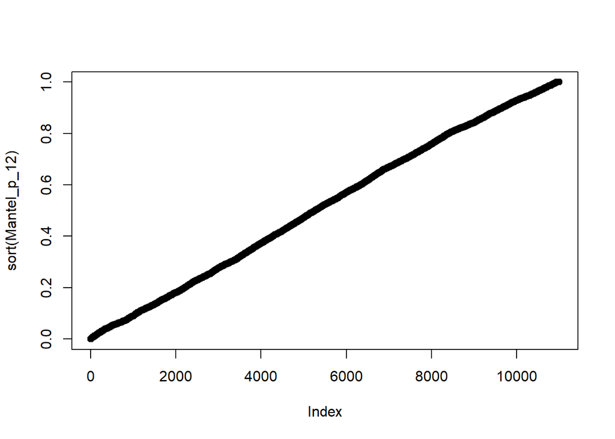

```r
Mantel_p_12 <- Mantel_p_1
Mantel_p_12[selected_genes] <- Mantel_p_2
plot(sort(Mantel_p_12))
```

### FDR

```r
q <- p.adjust(Mantel_p_12)
```

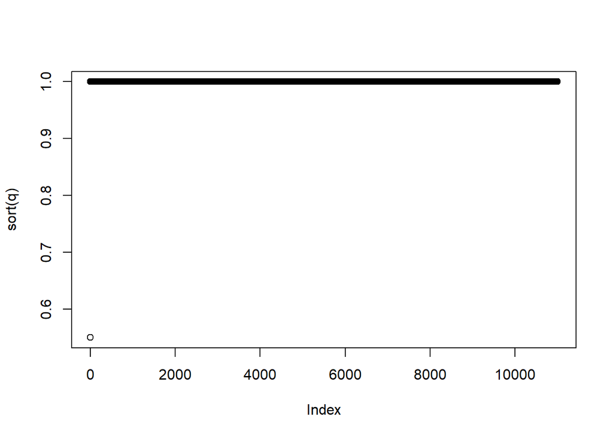

```r
plot(sort(q))
```

## 結果出力

```r
ret <- data.frame(gene.id=gene.id.non0s,Mantel_p_12=Mantel_p_12,Mantel_p_1 = Mantel_p_1, q.FDR=q,corrs=corrs)

write.table(ret,file="outLPSonly2.txt",sep="\t")
```